# Risk Factor Analysis

## Outcome Variable

**Outcome Variable:** y_rate_len

## Predictor Variables

**Intervention Variable:** perdiar24

**Adjustment Set:**

- arm
- sex
- meducyrs
- feducyrs
- hhwealth_quart
- hfoodsec
- vagbrth
- hdlvry
- W_birthwt
- W_birthlen
- W_nrooms
- month
- brthmon
- impfloor
- impsan
- safeh20
- delta_meducyrs
- delta_feducyrs
- delta_hhwealth_quart
- delta_hfoodsec
- delta_vagbrth
- delta_hdlvry
- delta_W_birthwt
- delta_W_birthlen
- delta_W_nrooms
- delta_month
- delta_brthmon
- delta_impfloor
- delta_impsan
- delta_safeh20

## Stratifying Variables

The analysis was stratified on these variable(s):

- agecat
- studyid
- country

## Data Summary

| agecat | studyid | country | perdiar24 | n_cell | n |
| --- | --- | --- | --- | --- | --- |
| 0-3 months | ki0047075b-MAL-ED | BANGLADESH | (0%, 5%] | 143 | 244 |
| 0-3 months | ki0047075b-MAL-ED | BANGLADESH | >5% | 93 | 244 |
| 0-3 months | ki0047075b-MAL-ED | BANGLADESH | 0% | 8 | 244 |
| 0-3 months | ki0047075b-MAL-ED | BRAZIL | (0%, 5%] | 81 | 180 |
| 0-3 months | ki0047075b-MAL-ED | BRAZIL | >5% | 2 | 180 |
| 0-3 months | ki0047075b-MAL-ED | BRAZIL | 0% | 97 | 180 |
| 0-3 months | ki0047075b-MAL-ED | INDIA | (0%, 5%] | 158 | 201 |
| 0-3 months | ki0047075b-MAL-ED | INDIA | >5% | 38 | 201 |
| 0-3 months | ki0047075b-MAL-ED | INDIA | 0% | 5 | 201 |
| 0-3 months | ki0047075b-MAL-ED | NEPAL | (0%, 5%] | 106 | 175 |
| 0-3 months | ki0047075b-MAL-ED | NEPAL | >5% | 57 | 175 |
| 0-3 months | ki0047075b-MAL-ED | NEPAL | 0% | 12 | 175 |
| 0-3 months | ki0047075b-MAL-ED | PERU | (0%, 5%] | 110 | 271 |
| 0-3 months | ki0047075b-MAL-ED | PERU | >5% | 151 | 271 |
| 0-3 months | ki0047075b-MAL-ED | PERU | 0% | 10 | 271 |
| 0-3 months | ki0047075b-MAL-ED | SOUTH AFRICA | (0%, 5%] | 151 | 229 |
| 0-3 months | ki0047075b-MAL-ED | SOUTH AFRICA | >5% | 3 | 229 |
| 0-3 months | ki0047075b-MAL-ED | SOUTH AFRICA | 0% | 75 | 229 |
| 0-3 months | ki0047075b-MAL-ED | TANZANIA, UNITED REPUBLIC OF | (0%, 5%] | 166 | 229 |
| 0-3 months | ki0047075b-MAL-ED | TANZANIA, UNITED REPUBLIC OF | >5% | 53 | 229 |
| 0-3 months | ki0047075b-MAL-ED | TANZANIA, UNITED REPUBLIC OF | 0% | 10 | 229 |
| 0-3 months | ki1000109-EE | PAKISTAN | (0%, 5%] | 130 | 594 |
| 0-3 months | ki1000109-EE | PAKISTAN | >5% | 30 | 594 |
| 0-3 months | ki1000109-EE | PAKISTAN | 0% | 434 | 594 |
| 0-3 months | ki1000109-ResPak | PAKISTAN | (0%, 5%] | 24 | 78 |
| 0-3 months | ki1000109-ResPak | PAKISTAN | >5% | 48 | 78 |
| 0-3 months | ki1000109-ResPak | PAKISTAN | 0% | 6 | 78 |
| 0-3 months | ki1017093-NIH-Birth | BANGLADESH | (0%, 5%] | 340 | 566 |
| 0-3 months | ki1017093-NIH-Birth | BANGLADESH | >5% | 197 | 566 |
| 0-3 months | ki1017093-NIH-Birth | BANGLADESH | 0% | 29 | 566 |

[output cut: 183 more lines]

The following strata were considered:

- agecat: 0-3 months, studyid: ki0047075b-MAL-ED, country: BANGLADESH
- agecat: 0-3 months, studyid: ki0047075b-MAL-ED, country: BRAZIL
- agecat: 0-3 months, studyid: ki0047075b-MAL-ED, country: INDIA
- agecat: 0-3 months, studyid: ki0047075b-MAL-ED, country: NEPAL
- agecat: 0-3 months, studyid: ki0047075b-MAL-ED, country: PERU
- agecat: 0-3 months, studyid: ki0047075b-MAL-ED, country: SOUTH AFRICA
- agecat: 0-3 months, studyid: ki0047075b-MAL-ED, country: TANZANIA, UNITED REPUBLIC OF
- agecat: 0-3 months, studyid: ki1000109-EE, country: PAKISTAN
- agecat: 0-3 months, studyid: ki1000109-ResPak, country: PAKISTAN
- agecat: 0-3 months, studyid: ki1017093-NIH-Birth, country: BANGLADESH
- agecat: 0-3 months, studyid: ki1017093b-PROVIDE, country: BANGLADESH
- agecat: 0-3 months, studyid: ki1017093c-NIH-Crypto, country: BANGLADESH
- agecat: 0-3 months, studyid: ki1114097-CMIN, country: BANGLADESH
- agecat: 0-3 months, studyid: ki1114097-CMIN, country: BRAZIL
- agecat: 0-3 months, studyid: ki1114097-CMIN, country: GUINEA-BISSAU
- agecat: 0-3 months, studyid: ki1114097-CMIN, country: PERU
- agecat: 0-3 months, studyid: ki1114097-CONTENT, country: PERU
- agecat: 0-3 months, studyid: kiGH5241-JiVitA-4, country: BANGLADESH
- agecat: 12-24 months, studyid: ki0047075b-MAL-ED, country: BANGLADESH
- agecat: 12-24 months, studyid: ki0047075b-MAL-ED, country: BRAZIL
- agecat: 12-24 months, studyid: ki0047075b-MAL-ED, country: INDIA
- agecat: 12-24 months, studyid: ki0047075b-MAL-ED, country: NEPAL
- agecat: 12-24 months, studyid: ki0047075b-MAL-ED, country: PERU
- agecat: 12-24 months, studyid: ki0047075b-MAL-ED, country: SOUTH AFRICA
- agecat: 12-24 months, studyid: ki0047075b-MAL-ED, country: TANZANIA, UNITED REPUBLIC OF
- agecat: 12-24 months, studyid: ki1017093-NIH-Birth, country: BANGLADESH
- agecat: 12-24 months, studyid: ki1017093b-PROVIDE, country: BANGLADESH
- agecat: 12-24 months, studyid: ki1017093c-NIH-Crypto, country: BANGLADESH
- agecat: 12-24 months, studyid: ki1114097-CMIN, country: BANGLADESH
- agecat: 12-24 months, studyid: ki1114097-CMIN, country: GUINEA-BISSAU
- agecat: 12-24 months, studyid: ki1114097-CMIN, country: PERU
- agecat: 12-24 months, studyid: ki1114097-CONTENT, country: PERU
- agecat: 12-24 months, studyid: kiGH5241-JiVitA-4, country: BANGLADESH
- agecat: 3-6 months, studyid: ki0047075b-MAL-ED, country: BANGLADESH
- agecat: 3-6 months, studyid: ki0047075b-MAL-ED, country: BRAZIL
- agecat: 3-6 months, studyid: ki0047075b-MAL-ED, country: INDIA
- agecat: 3-6 months, studyid: ki0047075b-MAL-ED, country: NEPAL
- agecat: 3-6 months, studyid: ki0047075b-MAL-ED, country: PERU
- agecat: 3-6 months, studyid: ki0047075b-MAL-ED, country: SOUTH AFRICA
- agecat: 3-6 months, studyid: ki0047075b-MAL-ED, country: TANZANIA, UNITED REPUBLIC OF
- agecat: 3-6 months, studyid: ki1000109-EE, country: PAKISTAN
- agecat: 3-6 months, studyid: ki1000109-ResPak, country: PAKISTAN
- agecat: 3-6 months, studyid: ki1017093-NIH-Birth, country: BANGLADESH
- agecat: 3-6 months, studyid: ki1017093b-PROVIDE, country: BANGLADESH
- agecat: 3-6 months, studyid: ki1017093c-NIH-Crypto, country: BANGLADESH
- agecat: 3-6 months, studyid: ki1114097-CMIN, country: BANGLADESH
- agecat: 3-6 months, studyid: ki1114097-CMIN, country: BRAZIL
- agecat: 3-6 months, studyid: ki1114097-CMIN, country: GUINEA-BISSAU
- agecat: 3-6 months, studyid: ki1114097-CMIN, country: PERU
- agecat: 3-6 months, studyid: ki1114097-CONTENT, country: PERU
- agecat: 3-6 months, studyid: kiGH5241-JiVitA-4, country: BANGLADESH
- agecat: 6-12 months, studyid: ki0047075b-MAL-ED, country: BANGLADESH
- agecat: 6-12 months, studyid: ki0047075b-MAL-ED, country: BRAZIL
- agecat: 6-12 months, studyid: ki0047075b-MAL-ED, country: INDIA
- agecat: 6-12 months, studyid: ki0047075b-MAL-ED, country: NEPAL
- agecat: 6-12 months, studyid: ki0047075b-MAL-ED, country: PERU
- agecat: 6-12 months, studyid: ki0047075b-MAL-ED, country: SOUTH AFRICA
- agecat: 6-12 months, studyid: ki0047075b-MAL-ED, country: TANZANIA, UNITED REPUBLIC OF
- agecat: 6-12 months, studyid: ki1000109-EE, country: PAKISTAN
- agecat: 6-12 months, studyid: ki1000109-ResPak, country: PAKISTAN
- agecat: 6-12 months, studyid: ki1000304b-SAS-FoodSuppl, country: INDIA
- agecat: 6-12 months, studyid: ki1017093-NIH-Birth, country: BANGLADESH
- agecat: 6-12 months, studyid: ki1017093b-PROVIDE, country: BANGLADESH
- agecat: 6-12 months, studyid: ki1017093c-NIH-Crypto, country: BANGLADESH
- agecat: 6-12 months, studyid: ki1112895-Guatemala BSC, country: GUATEMALA
- agecat: 6-12 months, studyid: ki1114097-CMIN, country: BANGLADESH
- agecat: 6-12 months, studyid: ki1114097-CMIN, country: BRAZIL
- agecat: 6-12 months, studyid: ki1114097-CMIN, country: GUINEA-BISSAU
- agecat: 6-12 months, studyid: ki1114097-CMIN, country: PERU
- agecat: 6-12 months, studyid: ki1114097-CONTENT, country: PERU
- agecat: 6-12 months, studyid: kiGH5241-JiVitA-4, country: BANGLADESH

### Dropped Strata

Some strata were dropped due to rare outcomes:

- agecat: 0-3 months, studyid: ki0047075b-MAL-ED, country: BRAZIL
- agecat: 0-3 months, studyid: ki0047075b-MAL-ED, country: SOUTH AFRICA
- agecat: 0-3 months, studyid: ki1114097-CMIN, country: BANGLADESH
- agecat: 0-3 months, studyid: ki1114097-CMIN, country: BRAZIL
- agecat: 0-3 months, studyid: ki1114097-CMIN, country: GUINEA-BISSAU
- agecat: 0-3 months, studyid: ki1114097-CMIN, country: PERU
- agecat: 0-3 months, studyid: ki1114097-CONTENT, country: PERU
- agecat: 3-6 months, studyid: ki0047075b-MAL-ED, country: BRAZIL
- agecat: 3-6 months, studyid: ki0047075b-MAL-ED, country: INDIA
- agecat: 3-6 months, studyid: ki0047075b-MAL-ED, country: SOUTH AFRICA
- agecat: 3-6 months, studyid: ki1114097-CMIN, country: BANGLADESH
- agecat: 3-6 months, studyid: ki1114097-CMIN, country: BRAZIL
- agecat: 3-6 months, studyid: ki1114097-CMIN, country: GUINEA-BISSAU
- agecat: 6-12 months, studyid: ki0047075b-MAL-ED, country: BRAZIL
- agecat: 6-12 months, studyid: ki0047075b-MAL-ED, country: INDIA
- agecat: 6-12 months, studyid: ki0047075b-MAL-ED, country: PERU
- agecat: 6-12 months, studyid: ki0047075b-MAL-ED, country: SOUTH AFRICA
- agecat: 6-12 months, studyid: ki1000109-EE, country: PAKISTAN
- agecat: 6-12 months, studyid: ki1000109-ResPak, country: PAKISTAN
- agecat: 6-12 months, studyid: ki1114097-CMIN, country: BANGLADESH
- agecat: 6-12 months, studyid: ki1114097-CMIN, country: BRAZIL
- agecat: 6-12 months, studyid: ki1114097-CMIN, country: GUINEA-BISSAU
- agecat: 12-24 months, studyid: ki0047075b-MAL-ED, country: BRAZIL
- agecat: 12-24 months, studyid: ki0047075b-MAL-ED, country: INDIA
- agecat: 12-24 months, studyid: ki0047075b-MAL-ED, country: PERU
- agecat: 12-24 months, studyid: ki0047075b-MAL-ED, country: SOUTH AFRICA
- agecat: 12-24 months, studyid: ki1114097-CMIN, country: BANGLADESH
- agecat: 12-24 months, studyid: ki1114097-CMIN, country: GUINEA-BISSAU
- agecat: 12-24 months, studyid: ki1114097-CONTENT, country: PERU

## Methods Detail

We’re interested in the causal parameters $E[Y_a]$ for all values of $a \in \mathcal{A}$. These parameters represent the mean outcome if, possibly contrary to fact, we intervened to set all units to have $A=a$. Under the randomization and positivity assumptions, these are identified by the statistical parameters $\psi_a=E_W[E_{Y|A,W}(Y|A=a,W)]$. In addition, we’re interested in the mean of $Y$, $E[Y]$ under no intervention (the observed mean). We will estimate these parameters by using SuperLearner to fit the relevant likelihood factors – $E_{Y|A,W}(Y|A=a,W)$ and $p(A=a|W)$, and then updating our likelihood fit using a joint TMLE.

For unadjusted analyses ($W=\{\}$), initial likelihoods were estimated using Lrnr_glm to estimate the simple $E(Y|A)$ and Lrnr_mean to estimate $p(A)$. For adjusted analyses, a small library containing Lrnr_glmnet, Lrnr_xgboost, and Lrnr_mean was used.

Having estimated these parameters, we will then use the delta method to estimate relative risks and attributable risks relative to a prespecified baseline level of $A$.

# Results Detail

## Results Plots

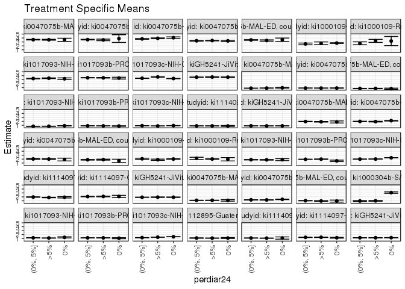

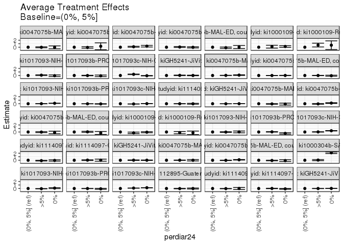

## Results Table

### Parameter: TSM

| agecat | studyid | country | intervention_level | baseline_level | estimate | ci_lower | ci_upper |
| --- | --- | --- | --- | --- | --- | --- | --- |
| 0-3 months | ki0047075b-MAL-ED | BANGLADESH | (0%, 5%] | NA | 3.5719582 | 3.4939801 | 3.6499363 |
| 0-3 months | ki0047075b-MAL-ED | BANGLADESH | >5% | NA | 3.5524375 | 3.4448799 | 3.6599950 |
| 0-3 months | ki0047075b-MAL-ED | BANGLADESH | 0% | NA | 3.5392256 | 3.1366004 | 3.9418508 |
| 0-3 months | ki0047075b-MAL-ED | INDIA | (0%, 5%] | NA | 3.5829200 | 3.5009030 | 3.6649370 |
| 0-3 months | ki0047075b-MAL-ED | INDIA | >5% | NA | 3.5138535 | 3.3161103 | 3.7115967 |
| 0-3 months | ki0047075b-MAL-ED | INDIA | 0% | NA | 3.8477798 | 2.8667723 | 4.8287874 |
| 0-3 months | ki0047075b-MAL-ED | NEPAL | (0%, 5%] | NA | 3.7743372 | 3.6812174 | 3.8674570 |
| 0-3 months | ki0047075b-MAL-ED | NEPAL | >5% | NA | 3.9119499 | 3.8084288 | 4.0154710 |
| 0-3 months | ki0047075b-MAL-ED | NEPAL | 0% | NA | 4.0694720 | 3.8497221 | 4.2892220 |
| 0-3 months | ki0047075b-MAL-ED | PERU | (0%, 5%] | NA | 3.2933297 | 3.2049828 | 3.3816766 |
| 0-3 months | ki0047075b-MAL-ED | PERU | >5% | NA | 3.3492684 | 3.2679078 | 3.4306290 |
| 0-3 months | ki0047075b-MAL-ED | PERU | 0% | NA | 3.2663450 | 3.1295974 | 3.4030925 |
| 0-3 months | ki0047075b-MAL-ED | TANZANIA, UNITED REPUBLIC OF | (0%, 5%] | NA | 3.4991487 | 3.4136929 | 3.5846045 |
| 0-3 months | ki0047075b-MAL-ED | TANZANIA, UNITED REPUBLIC OF | >5% | NA | 3.3645493 | 3.2017793 | 3.5273193 |
| 0-3 months | ki0047075b-MAL-ED | TANZANIA, UNITED REPUBLIC OF | 0% | NA | 3.5449278 | 3.1045521 | 3.9853035 |
| 0-3 months | ki1000109-EE | PAKISTAN | (0%, 5%] | NA | 2.4962163 | 2.2790213 | 2.7134113 |
| 0-3 months | ki1000109-EE | PAKISTAN | >5% | NA | 2.6510347 | 2.3003457 | 3.0017237 |
| 0-3 months | ki1000109-EE | PAKISTAN | 0% | NA | 2.7064167 | 2.6182537 | 2.7945798 |
| 0-3 months | ki1000109-ResPak | PAKISTAN | (0%, 5%] | NA | 2.6501201 | 2.2768900 | 3.0233502 |
| 0-3 months | ki1000109-ResPak | PAKISTAN | >5% | NA | 3.2665868 | 2.8798234 | 3.6533502 |
| 0-3 months | ki1000109-ResPak | PAKISTAN | 0% | NA | 3.2270347 | 2.0591313 | 4.3949381 |
| 0-3 months | ki1017093-NIH-Birth | BANGLADESH | (0%, 5%] | NA | 3.2889218 | 3.2231602 | 3.3546835 |
| 0-3 months | ki1017093-NIH-Birth | BANGLADESH | >5% | NA | 3.3685145 | 3.2795685 | 3.4574606 |
| 0-3 months | ki1017093-NIH-Birth | BANGLADESH | 0% | NA | 3.2289648 | 3.0082436 | 3.4496861 |
| 0-3 months | ki1017093b-PROVIDE | BANGLADESH | (0%, 5%] | NA | 3.4895380 | 3.4448924 | 3.5341836 |
| 0-3 months | ki1017093b-PROVIDE | BANGLADESH | >5% | NA | 3.4732758 | 3.4066976 | 3.5398540 |
| 0-3 months | ki1017093b-PROVIDE | BANGLADESH | 0% | NA | 3.3954828 | 3.1748022 | 3.6161634 |
| 0-3 months | ki1017093c-NIH-Crypto | BANGLADESH | (0%, 5%] | NA | 3.3625518 | 3.3149553 | 3.4101483 |
| 0-3 months | ki1017093c-NIH-Crypto | BANGLADESH | >5% | NA | 3.6924841 | 3.6380675 | 3.7469007 |
| 0-3 months | ki1017093c-NIH-Crypto | BANGLADESH | 0% | NA | 3.2931582 | 3.2540371 | 3.3322794 |

[output cut: 96 more lines]

### Parameter: E(Y)

| agecat | studyid | country | intervention_level | baseline_level | estimate | ci_lower | ci_upper |
| --- | --- | --- | --- | --- | --- | --- | --- |
| 0-3 months | ki0047075b-MAL-ED | BANGLADESH | NA | NA | 3.5634447 | 3.5006347 | 3.6262547 |
| 0-3 months | ki0047075b-MAL-ED | INDIA | NA | NA | 3.5764512 | 3.4977133 | 3.6551891 |
| 0-3 months | ki0047075b-MAL-ED | NEPAL | NA | NA | 3.8204935 | 3.7444190 | 3.8965681 |
| 0-3 months | ki0047075b-MAL-ED | PERU | NA | NA | 3.3158605 | 3.2526447 | 3.3790763 |
| 0-3 months | ki0047075b-MAL-ED | TANZANIA, UNITED REPUBLIC OF | NA | NA | 3.4816904 | 3.4044928 | 3.5588880 |
| 0-3 months | ki1000109-EE | PAKISTAN | NA | NA | 2.6575645 | 2.5739973 | 2.7411317 |
| 0-3 months | ki1000109-ResPak | PAKISTAN | NA | NA | 3.0738623 | 2.7876913 | 3.3600332 |
| 0-3 months | ki1017093-NIH-Birth | BANGLADESH | NA | NA | 3.3129255 | 3.2581305 | 3.3677204 |
| 0-3 months | ki1017093b-PROVIDE | BANGLADESH | NA | NA | 3.4826706 | 3.4434873 | 3.5218539 |
| 0-3 months | ki1017093c-NIH-Crypto | BANGLADESH | NA | NA | 3.3028656 | 3.2646714 | 3.3410598 |
| 0-3 months | kiGH5241-JiVitA-4 | BANGLADESH | NA | NA | 3.6381167 | 3.6070177 | 3.6692156 |
| 3-6 months | ki0047075b-MAL-ED | BANGLADESH | NA | NA | 1.9280462 | 1.8787523 | 1.9773401 |
| 3-6 months | ki0047075b-MAL-ED | NEPAL | NA | NA | 1.9680995 | 1.9120346 | 2.0241643 |
| 3-6 months | ki0047075b-MAL-ED | PERU | NA | NA | 2.0183213 | 1.9525900 | 2.0840526 |
| 3-6 months | ki0047075b-MAL-ED | TANZANIA, UNITED REPUBLIC OF | NA | NA | 1.8300902 | 1.7622436 | 1.8979368 |
| 3-6 months | ki1000109-EE | PAKISTAN | NA | NA | 2.0241201 | 1.9636505 | 2.0845898 |
| 3-6 months | ki1000109-ResPak | PAKISTAN | NA | NA | 2.0694234 | 1.9275918 | 2.2112551 |
| 3-6 months | ki1017093-NIH-Birth | BANGLADESH | NA | NA | 1.8326915 | 1.7846731 | 1.8807099 |
| 3-6 months | ki1017093b-PROVIDE | BANGLADESH | NA | NA | 1.9654454 | 1.9303798 | 2.0005110 |
| 3-6 months | ki1017093c-NIH-Crypto | BANGLADESH | NA | NA | 2.0057973 | 1.9693775 | 2.0422170 |
| 3-6 months | ki1114097-CMIN | PERU | NA | NA | 1.8940471 | 1.8464513 | 1.9416429 |
| 3-6 months | ki1114097-CONTENT | PERU | NA | NA | 2.0841841 | 2.0362519 | 2.1321163 |
| 3-6 months | kiGH5241-JiVitA-4 | BANGLADESH | NA | NA | 1.8983676 | 1.8684335 | 1.9283018 |
| 6-12 months | ki0047075b-MAL-ED | BANGLADESH | NA | NA | 1.1143928 | 1.0896103 | 1.1391753 |
| 6-12 months | ki0047075b-MAL-ED | NEPAL | NA | NA | 1.2224454 | 1.1966480 | 1.2482429 |
| 6-12 months | ki0047075b-MAL-ED | TANZANIA, UNITED REPUBLIC OF | NA | NA | 1.0019524 | 0.9648566 | 1.0390481 |
| 6-12 months | ki1000304b-SAS-FoodSuppl | INDIA | NA | NA | 1.0131058 | 0.9370457 | 1.0891660 |
| 6-12 months | ki1017093-NIH-Birth | BANGLADESH | NA | NA | 1.1679344 | 1.1454934 | 1.1903754 |
| 6-12 months | ki1017093b-PROVIDE | BANGLADESH | NA | NA | 1.1731762 | 1.1558671 | 1.1904853 |
| 6-12 months | ki1017093c-NIH-Crypto | BANGLADESH | NA | NA | 1.2281313 | 1.2106849 | 1.2455776 |
| 6-12 months | ki1112895-Guatemala BSC | GUATEMALA | NA | NA | 1.1083850 | 1.0774528 | 1.1393172 |
| 6-12 months | ki1114097-CMIN | PERU | NA | NA | 1.1101018 | 1.0850311 | 1.1351725 |
| 6-12 months | ki1114097-CONTENT | PERU | NA | NA | 1.3010517 | 1.2719491 | 1.3301542 |
| 6-12 months | kiGH5241-JiVitA-4 | BANGLADESH | NA | NA | 1.2032152 | 1.1928290 | 1.2136015 |
| 12-24 months | ki0047075b-MAL-ED | BANGLADESH | NA | NA | 0.8459764 | 0.8299714 | 0.8619814 |
| 12-24 months | ki0047075b-MAL-ED | NEPAL | NA | NA | 0.8617083 | 0.8463512 | 0.8770654 |
| 12-24 months | ki0047075b-MAL-ED | TANZANIA, UNITED REPUBLIC OF | NA | NA | 0.7663111 | 0.7428636 | 0.7897586 |
| 12-24 months | ki1017093-NIH-Birth | BANGLADESH | NA | NA | 0.7513013 | 0.7366996 | 0.7659029 |
| 12-24 months | ki1017093b-PROVIDE | BANGLADESH | NA | NA | 0.8575519 | 0.8455586 | 0.8695452 |
| 12-24 months | ki1017093c-NIH-Crypto | BANGLADESH | NA | NA | 0.8755729 | 0.8637860 | 0.8873598 |
| 12-24 months | ki1114097-CMIN | PERU | NA | NA | 0.8385504 | 0.8202134 | 0.8568875 |
| 12-24 months | kiGH5241-JiVitA-4 | BANGLADESH | NA | NA | 0.8492552 | 0.8437966 | 0.8547138 |

### Parameter: ATE

| agecat | studyid | country | intervention_level | baseline_level | estimate | ci_lower | ci_upper |
| --- | --- | --- | --- | --- | --- | --- | --- |
| 0-3 months | ki0047075b-MAL-ED | BANGLADESH | (0%, 5%] | (0%, 5%] | 0.0000000 | 0.0000000 | 0.0000000 |
| 0-3 months | ki0047075b-MAL-ED | BANGLADESH | >5% | (0%, 5%] | -0.0195207 | -0.1523710 | 0.1133296 |
| 0-3 months | ki0047075b-MAL-ED | BANGLADESH | 0% | (0%, 5%] | -0.0327326 | -0.4428394 | 0.3773743 |
| 0-3 months | ki0047075b-MAL-ED | INDIA | (0%, 5%] | (0%, 5%] | 0.0000000 | 0.0000000 | 0.0000000 |
| 0-3 months | ki0047075b-MAL-ED | INDIA | >5% | (0%, 5%] | -0.0690665 | -0.2831440 | 0.1450110 |
| 0-3 months | ki0047075b-MAL-ED | INDIA | 0% | (0%, 5%] | 0.2648598 | -0.7195702 | 1.2492899 |
| 0-3 months | ki0047075b-MAL-ED | NEPAL | (0%, 5%] | (0%, 5%] | 0.0000000 | 0.0000000 | 0.0000000 |
| 0-3 months | ki0047075b-MAL-ED | NEPAL | >5% | (0%, 5%] | 0.1376127 | 0.0009339 | 0.2742915 |
| 0-3 months | ki0047075b-MAL-ED | NEPAL | 0% | (0%, 5%] | 0.2951348 | 0.0585803 | 0.5316894 |
| 0-3 months | ki0047075b-MAL-ED | PERU | (0%, 5%] | (0%, 5%] | 0.0000000 | 0.0000000 | 0.0000000 |
| 0-3 months | ki0047075b-MAL-ED | PERU | >5% | (0%, 5%] | 0.0559386 | -0.0640835 | 0.1759608 |
| 0-3 months | ki0047075b-MAL-ED | PERU | 0% | (0%, 5%] | -0.0269848 | -0.1896804 | 0.1357109 |
| 0-3 months | ki0047075b-MAL-ED | TANZANIA, UNITED REPUBLIC OF | (0%, 5%] | (0%, 5%] | 0.0000000 | 0.0000000 | 0.0000000 |
| 0-3 months | ki0047075b-MAL-ED | TANZANIA, UNITED REPUBLIC OF | >5% | (0%, 5%] | -0.1345994 | -0.3185649 | 0.0493660 |
| 0-3 months | ki0047075b-MAL-ED | TANZANIA, UNITED REPUBLIC OF | 0% | (0%, 5%] | 0.0457791 | -0.4027929 | 0.4943511 |
| 0-3 months | ki1000109-EE | PAKISTAN | (0%, 5%] | (0%, 5%] | 0.0000000 | 0.0000000 | 0.0000000 |
| 0-3 months | ki1000109-EE | PAKISTAN | >5% | (0%, 5%] | 0.1548184 | -0.2566821 | 0.5663189 |
| 0-3 months | ki1000109-EE | PAKISTAN | 0% | (0%, 5%] | 0.2102004 | -0.0222615 | 0.4426624 |
| 0-3 months | ki1000109-ResPak | PAKISTAN | (0%, 5%] | (0%, 5%] | 0.0000000 | 0.0000000 | 0.0000000 |
| 0-3 months | ki1000109-ResPak | PAKISTAN | >5% | (0%, 5%] | 0.6164667 | 0.0789849 | 1.1539485 |
| 0-3 months | ki1000109-ResPak | PAKISTAN | 0% | (0%, 5%] | 0.5769146 | -0.6491764 | 1.8030055 |
| 0-3 months | ki1017093-NIH-Birth | BANGLADESH | (0%, 5%] | (0%, 5%] | 0.0000000 | 0.0000000 | 0.0000000 |
| 0-3 months | ki1017093-NIH-Birth | BANGLADESH | >5% | (0%, 5%] | 0.0795927 | -0.0264463 | 0.1856317 |
| 0-3 months | ki1017093-NIH-Birth | BANGLADESH | 0% | (0%, 5%] | -0.0599570 | -0.2889799 | 0.1690659 |
| 0-3 months | ki1017093b-PROVIDE | BANGLADESH | (0%, 5%] | (0%, 5%] | 0.0000000 | 0.0000000 | 0.0000000 |
| 0-3 months | ki1017093b-PROVIDE | BANGLADESH | >5% | (0%, 5%] | -0.0162622 | -0.0929586 | 0.0604342 |
| 0-3 months | ki1017093b-PROVIDE | BANGLADESH | 0% | (0%, 5%] | -0.0940552 | -0.3182094 | 0.1300990 |
| 0-3 months | ki1017093c-NIH-Crypto | BANGLADESH | (0%, 5%] | (0%, 5%] | 0.0000000 | 0.0000000 | 0.0000000 |
| 0-3 months | ki1017093c-NIH-Crypto | BANGLADESH | >5% | (0%, 5%] | 0.3299323 | 0.2557396 | 0.4041250 |
| 0-3 months | ki1017093c-NIH-Crypto | BANGLADESH | 0% | (0%, 5%] | -0.0693936 | -0.1305956 | -0.0081915 |

[output cut: 96 more lines]